# Traffic Flow & Street Network Analysis

2640019

1732 words

# Introduction

A city’s transportation system is very important to the development of modern cities, in today’s urban development due to many families have purchased a car, which exacerbates the situation of urban traffic jams, especially when commuting to and from work during peak hours when many sections of the road may be blocked for an hour, which not only affects people’s daily travel, but also affects the city’s normal logistics and transportation. This phenomenon shows that the street network on the way people travel and urban logistics and transportation have an inseparable correlation, if we can analyze the past urban road traffic data, according to the results of the analysis in advance to predict those places that may produce congestion, it can be more reasonable to help people choose the path of travel, while more reasonable planning of urban transportation construction, which is conducive to the government to plan urban transportation infrastructure and the introduction of new traffic jams. This is conducive to the government’s planning of urban transportation infrastructure and the introduction of new policies. At the same time, it is also conducive to the optimization of navigation routes by network navigation systems, so as to provide more reasonable route planning for people’s travel. It rationalizes the urban transportation system in many ways, which is convenient for the public to travel and the city to be built. In R the street network can be processed as an image and then analyzed, because each road intersection (intersection) in the image is a node, and the road is the line, so we can use the image to analyze the structure of the street and determine the key road intersections and roads. Simply by adding the collected traffic dataset to the analysis, we can study the rate of change of traffic volume over time at each interchange and roadway, and the relationship between traffic volume and the structure of the traffic network. The two datasets I used for data analysis in this report are adjacency matrix and time-series traffic data. adjacency matrix is used to generate node connections in r and see how the nodes are connected in the image, while time-series traffic data is used to record the traffic volume of each road. traffic data is to record the traffic size of each road at different points in time. By analyzing these two data, it can be analyzed that those traffic intersections in this experimental case are the ones that have the most impact on the traffic flow and it can also be said that that traffic node is more important. It is also possible to get how the traffic flow varies during the time of the data.Refer to the online resource (Tranos 2024).

# Data collection and downloading

1. Adjacency Matrix **`adj_matrix.csv`**: The adjacency matrix dataset (adj_matrix.csv) describes the connections between intersections in the street network. Each value in the matrix shows whether two nodes (intersections) are connected by a road. This matrix helps create a graph that represents the street network. The dataset was downloaded from a data-sharing platform. Before using it, the matrix was checked for errors, like missing or incorrect entries. If these problems are not fixed, the graph created from the matrix might not accurately represent the street network.

2.Traffic Data **`train.csv`** and **`test.csv`**: Time-series traffic data, including traffic volume and road attributes.The traffic data (train.csv and test.csv) includes time-series records of vehicle volumes and road attributes. It was collected from traffic sensors and cameras placed on roads. The data spans several weeks, providing information on how traffic changes throughout the day and week.

## Data Preparation

```r
library(tidyverse)
library(igraph)

# First need Load the data
adj_matrix <- read.csv("/Users/ts/Rdata/adj_matrix.csv", row.names = 1)
train_data <- read.csv("/Users/ts/Rdata/train.csv")
test_data <- read.csv("/Users/ts/Rdata/test.csv")

# Next Preview the data
head(adj_matrix)
```

```
##   X0 X1 X2 X3 X4 X5 X6 X7 X8 X9 X10 X11 X12 X13 X14 X15 X16 X17 X18 X19 X20 X21
## 0  0  1  0  0  0  0  0  0  0  0   0   0   0   0   1   0   0   0   0   0   0   0
## 1  1  0  1  0  0  0  0  0  0  0   0   0   0   0   0   0   0   0   0   0   0   0
## 2  0  1  0  1  0  0  0  0  0  0   0   0   0   0   0   0   0   0   0   0   0   0
## 3  0  0  1  0  0  0  0  0  0  0   0   0   0   0   0   0   0   0   0   0   0   0
## 4  0  0  0  0  0  1  0  0  0  0   0   0   0   0   0   0   0   0   0   0   0   1
## 5  0  0  0  0  1  0  1  0  0  0   0   0   0   0   0   0   0   0   0   0   0   0
##   X22 X23 X24 X25 X26 X27 X28 X29 X30 X31 X32 X33 X34 X35
## 0   0   0   0   1   0   0   0   1   0   0   0   0   0   0
## 1   0   0   0   0   0   0   0   0   0   0   0   0   0   0
## 2   0   0   0   0   0   0   0   0   0   0   0   0   0   0
## 3   0   0   0   0   0   0   0   0   0   0   0   0   0   0
## 4   0   0   0   1   1   0   0   0   0   1   0   0   0   0
## 5   0   0   0   0   0   0   0   0   0   0   0   0   0   0
```

```r
head(train_data)
```

```
##   X timestep location    traffic     prev_1     prev_2     prev_3     prev_4
## 1 0        0        0 0.05091079 0.09248015 0.09668379 0.07006072 0.06585708
## 2 1        0        1 0.04624007 0.09715086 0.10228865 0.08173751 0.07659972
## 3 2        0        2 0.05044372 0.11536665 0.11069594 0.10555815 0.09528258
## 4 3        0        3 0.04483886 0.11209715 0.10275572 0.09201308 0.08360579
## 5 4        0        4 0.04483886 0.12704344 0.15086408 0.13171415 0.10602522
## 6 5        0        5 0.04530593 0.12517515 0.14292387 0.11583372 0.09154601
##       prev_5     prev_6     prev_7     prev_8     prev_9    prev_10 feata_1
## 1 0.07846801 0.07146193 0.05418029 0.04437179 0.05464736 0.05091079       1
## 2 0.07239608 0.06772536 0.05885100 0.06632415 0.05978515 0.05698272       1
## 3 0.06772536 0.08033629 0.06258758 0.06165343 0.05558150 0.06165343       1
## 4 0.06212050 0.07099486 0.05371322 0.06258758 0.05371322 0.06679122       1
## 5 0.09901915 0.09061186 0.06912658 0.06071929 0.06071929 0.06725829       1
## 6 0.09481551 0.07846801 0.07192901 0.05371322 0.05091079 0.06772536       1
##   feata_2 feata_3 feata_4 feata_5 hour_1 hour_2 hour_3 hour_4 hour_5 hour_6
```

[output cut: 27 more lines]

# Street Network Graph

Using the adjacency matrix, the street network was turned into a graph. In this graph: • Nodes represent intersections. • Edges represent roads connecting intersections.

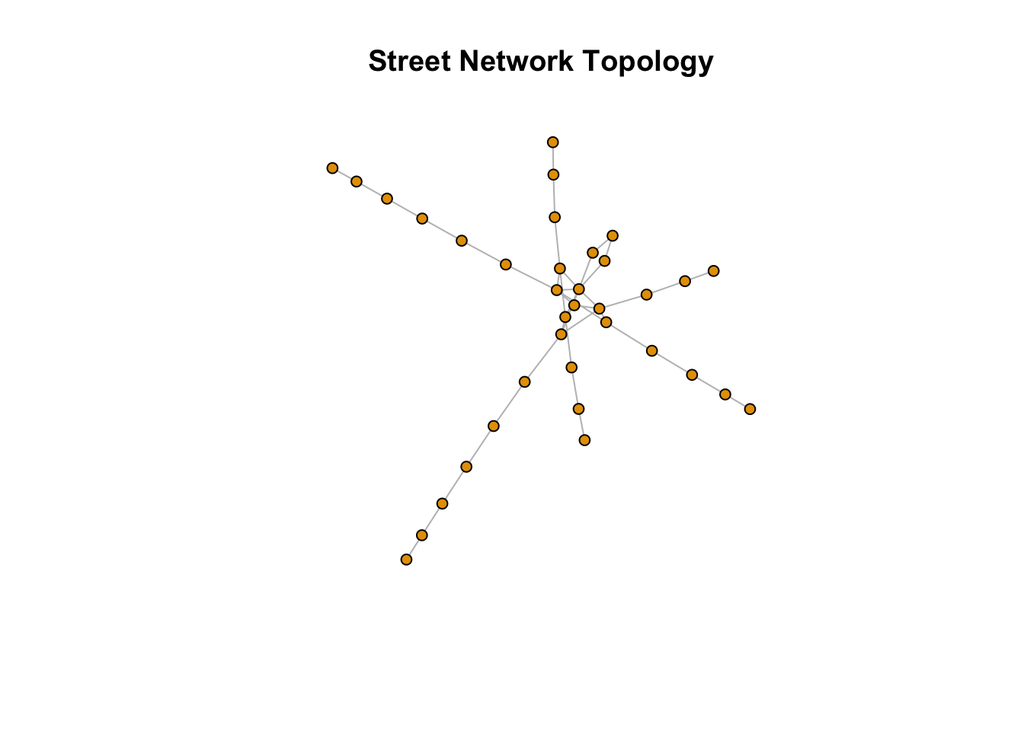

```r
# At first need create a graph from the adjacency matrix
graph <- graph_from_adjacency_matrix(as.matrix(adj_matrix), mode = "undirected")
# Next need visualize the graph
plot(graph,
     vertex.size = 5,
     vertex.label=NA,
     edge.color = "gray",
     main = "Street Network Topology")
```

# Traffic Flow Analysis

We need preprocessing Traffic Data

```r
library(lubridate)

# First convert timestep to datetime format
train_data <- train_data %>%
  mutate(timestamp = as.POSIXct(timestep * 900, origin = "2022-01-01", tz = "UTC"))

# Next aggregate traffic volume by hour
hourly_traffic <- train_data %>%
  mutate(hour = floor_date(timestamp, "hour")) %>%
  group_by(location, hour) %>%
  summarize(total_traffic = sum(traffic, na.rm = TRUE), .groups = "drop")
```

# Traffic Flow Visualization

```r
library(scales)
```

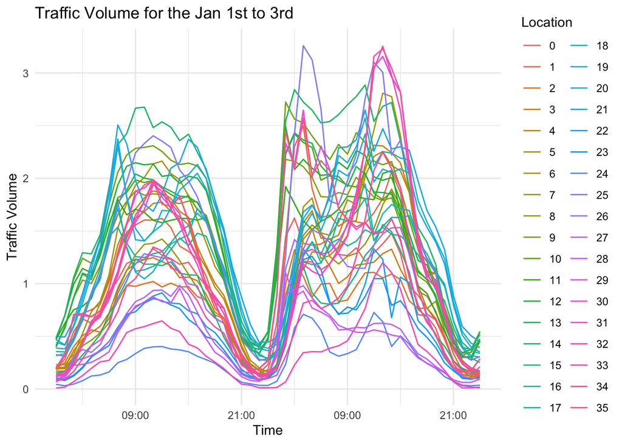

```r
ggplot(hourly_traffic %>%
filter(hour >= as.POSIXct("2022-01-01") & hour <= as.POSIXct("2022-01-03")),
      aes(x = hour,
          y = total_traffic,
      color = as.factor(location))) +
geom_line() +
scale_x_datetime(date_breaks = "12 hours", date_labels = "%H:%M") +
labs(title = "Traffic Volume for the Jan 1st to 3rd",
          x = "Time",
          y = "Traffic Volume",
      color = "Location") +
theme_minimal()
```

# Centrality Analysis & Street Network Analysis

Based on the structural map of the street network we generated, we can infer that those intersections are critical points and those intersections are more irreplaceable by analyzing the degree of centrality of the nodes; the frequency and number of links between individual nodes and the tightness of the connections between individual nodes.

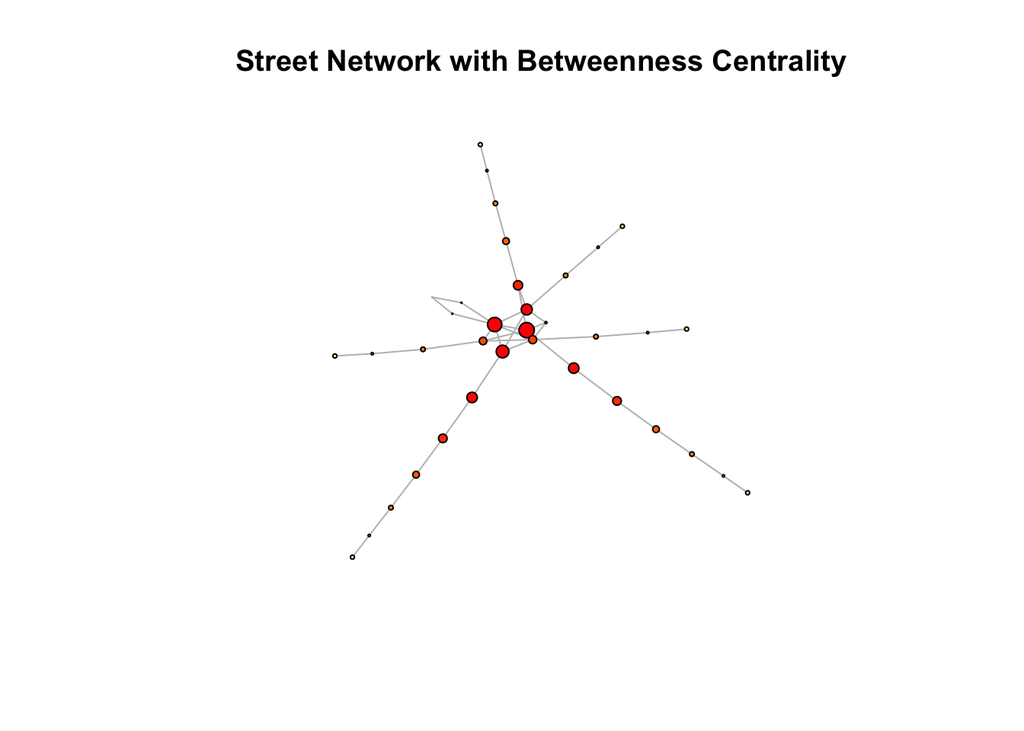

```r
# First need compute betweenness centrality
betweenness_centrality <- betweenness(graph, normalized = TRUE)

# Next add centrality to graph nodes
V(graph)$betweenness <- betweenness_centrality

# At last visualize the graph with betweenness centrality
plot(graph,
     vertex.size = V(graph)$betweenness*20,
     vertex.label=NA,
     vertex.color=heat.colors(length(V(graph)))[rank(-V(graph)$betweenness)],
     edge.color = "gray",
     main = "Street Network with Betweenness Centrality")
```

## Findings

1. We can see in the image that the node of center is the largest, so we can conclude that red is the key intersection, which is our key node.
2. At the same time, we can see that in the image there are a lot of highly connected nodes, but there are also a lot of intersections in the surrounding area that are not so highly connected, which is a typical feature of the city, which needs some nodes to connect the edge of the city.
3. We can analyze the key nodes that are irreplaceable and have the highest probability of being affected, because there is no alternative, so if the node is congested, it may lead to a large number of road congestion and the probability of not being able to evacuate the road successfully in a short time.

# Integrated Analysis

Combining network centrality and traffic flow data reveals the relationship between key intersections and traffic patterns. next we need mix Data together

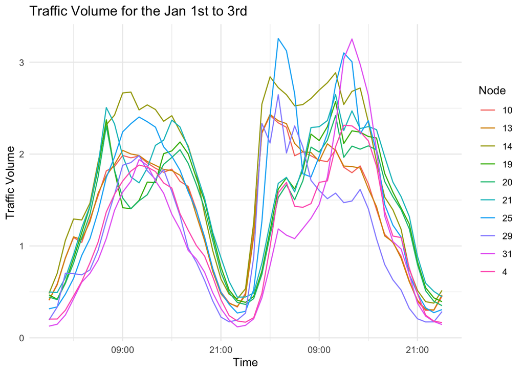

```r
# Identify key nodes based on high betweenness centrality
key_nodes <- data.frame(node = V(graph)$name,
  betweenness = V(graph)$betweenness) %>%
  arrange(desc(betweenness)) %>%
  head(10)

# we need remove the alphabet in key_nodes
key_nodes <- key_nodes %>%
mutate(node_number = gsub("X", "", node))

# we need convert to character types to ensure consistent formatting
key_nodes$node_number <- as.character(key_nodes$node_number)
hourly_traffic$location <- as.character(hourly_traffic$location)

# next is filter traffic data corresponding to key nodes
key_node_traffic <- hourly_traffic %>%
filter(location %in% key_nodes$node_number)

# Visualize traffic data at key nodes
key_node_traffic_filtered <- key_node_traffic %>%
  filter(hour >= as.POSIXct("2022-01-01") & hour <= as.POSIXct("2022-01-03"))
ggplot(key_node_traffic_filtered,
   aes(x = hour,
       y =total_traffic,                                    color=as.factor(location))) +
  geom_line() +
  scale_x_datetime(date_breaks = "12 hours",
                   date_labels = "%H:%M") +
  labs(title = "Traffic Volume for the Jan 1st to 3rd",
       x = "Time",
       y = "Traffic Volume",
       color = "Node") +
  theme_minimal()
```

# Conclusion

I have analyzed the relationship between urban street networks and traffic flow by comparing central metrics with traffic data in this one report. It proves that combining network data with traffic data can help people to understand the city more deeply and provide some data to assist the city’s transportation and future urban planning. I have also come up with some of the following conclusions and recommendations. 1. key intersections in urban roads play an irreplaceable role in the urban transportation network and should be prioritized in road traffic management and urban renovation 2. Urban traffic fluctuates regularly, and both morning and evening peak traffic can be predicted so that traffic control and evacuation of roads can be carried out in advance. 3. the nodes in the road where traffic is easily congested and irreplaceable are retrofitted. Overall, the combination of images and traffic data also facilitates the understanding of urban transportation systems. Meanwhile, analyzing key intersection nodes and high traffic flow areas will make it easier for urban planners to design an efficient and convenient network. Meanwhile, due to the limited data in this report, more data and details such as public transportation or people flow data can be included in the actual study of large cities for a more comprehensive analysis.

Tranos, Emmanouil. 2024. “Urban Analytics and City Science: Street Networks.” https://github.com/etranos/urban_analytics_city_science/blob/local/src/street_networks.Rmd#L29.